# HANDS-ON ASSIGNMENT 1: BASIC PYTHON

Nama:

```python
print("Rahman Aziz Firmansyah")
```

```
Rahman Aziz Firmansyah
```

Email:

```python
print("rahmanazizf@gmail.com")
```

```
rahmanazizf@gmail.com
```

(1) Buat 4 variabel dengan 4 tipe data yang berbeda: float, integer, string, dan boolean. Print masing-masing variabel beserta tipenya

```python
var_float = 9.79
var_int = 76
var_str = "hands-on assignment 1"
var_bool = True
print(var_float)
print(type(var_float))
print(var_int)
print(type(var_int))
print(var_str)
print(type(var_str))
print(var_bool)
print(type(var_bool))
```

```
9.79
<class 'float'>
76
<class 'int'>
hands-on assignment 1
<class 'str'>
True
<class 'bool'>
```

(2) Buat variabel yang mengandung list berisi 4 elemen (bebas). Tambahkan elemen ke lima. Ubah elemen ke 3. Hapus elemen ke 2. Print hasil akhirnya.

```python
#list berisi 4 elemen
list_day1 = [var_int, var_bool, var_float, var_str]
#tambah elemen ke-5
list_day1.append("day one")
#ubah elemen ke-3
list_day1[2] = 7.77
#hapus elemen ke-2
del list_day1[1]
print(list_day1)
```

```
[76, 7.77, 'hands-on assignment 1', 'day one']
```

(3) Buat variabel yang mengandung dictionary ibukota_provinsi berisi 6 pasangan provinsi-ibukota (bebas). Tambahkan pasangan ke tujuh. Ubah value pada key ke-3. Hapus pasangan ke 2. Dengan menggunakan loop, print kalimat "Ibukota provinsi ... adalah ..." untuk masing-masing pasangat key-value.

```python
ibukota_provinsi = {'Banten':'Serang', 'Jawa Barat':'Bandung', 'Jawa Tengah':'Solo', 'Jawa Timur':'Surabaya', 'Bali':'Denpasar', 'Papua':'Jayapura'}
ibukota_provinsi['Riau'] = 'Pekanbaru'
ibukota_provinsi[list(ibukota_provinsi.keys())[2]] = 'Semarang'
del(ibukota_provinsi[list(ibukota_provinsi.keys())[1]])

for prov, ik in ibukota_provinsi.items():
    print("Ibukota provinsi {} adalah {}".format(prov, ik))
```

```
Ibukota provinsi Banten adalah Serang
Ibukota provinsi Jawa Tengah adalah Semarang
Ibukota provinsi Jawa Timur adalah Surabaya
Ibukota provinsi Bali adalah Denpasar
Ibukota provinsi Papua adalah Jayapura
Ibukota provinsi Riau adalah Pekanbaru
```

(4) Buat 3 list. List pertama berisi 5 nama atlet. List kedua berisi 5 cabang olahraga. List ketiga berisi 5 negara asal. Dengan menggunakan for loop 3 variabel buatlah 5 kalimat dengan format:

Atlet bernama ... merupakan atlet cabang olahraga ... yang berasal dari negara ...

```python
nama_atlet = ['Stephen Curry', 'Kevin Durant', 'Christiano Ronaldo', 'Usain Bolt', 'Lionel Messi']
cabor = ['Basket', 'Basket', 'Sepak bola', 'Lari', 'Sepak bola']
negara = ['Amerika', 'Amerika', 'Portugal', 'Jamaika', 'Argentina']
for nama, cabor, negara in zip(nama_atlet, cabor, negara):
    print("Atlet bernama {} merupakan atlet cabang olahraga {} yang berasal dari negara {}".format(nama, cabor, negara))
```

```
Atlet bernama Stephen Curry merupakan atlet cabang olahraga Basket yang berasal dari negara Amerika
Atlet bernama Kevin Durant merupakan atlet cabang olahraga Basket yang berasal dari negara Amerika
Atlet bernama Christiano Ronaldo merupakan atlet cabang olahraga Sepak bola yang berasal dari negara Portugal
Atlet bernama Usain Bolt merupakan atlet cabang olahraga Lari yang berasal dari negara Jamaika
Atlet bernama Lionel Messi merupakan atlet cabang olahraga Sepak bola yang berasal dari negara Argentina
```

(5) Buat 2 array x dan y, masing-masing memiliki 10 bilangan bulat yang di-generate menggunakan fungsi number generator dari library numpy. Buat scatter plot dengan menggunakan array x sebagai nilai axis x dan array y sebagai nilai axis y. Tambahkan title, label x, dan label y (bebas).

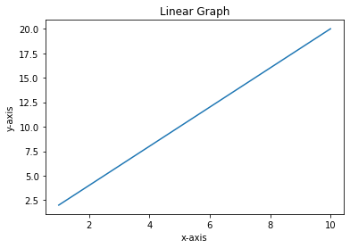

```python
import numpy as np
import matplotlib.pyplot as plt

x = np.linspace(1, 10, 10)
y = np.linspace(2, 20, 10)
plt.plot(x, y)
plt.title("Linear Graph")
plt.xlabel("x-axis")
plt.ylabel("y-axis")
plt.show()
```

(6) Import covid.csv sebagai dataframe. Lakukan grouping dengan menggunakan kolom 'Country/Region' dan 'Date' sebagai acuan, dan gunakan .sum() sebagai metode agregasi. Lakukan reset index. Gunakan fungsi pd.to_datetime() untuk mengubah tipe data pada kolom 'Date'.

Buat lineplot untuk data kasus aktiv (data kolom 'Active') untuk negara US, United Kingdom, Italy, India, Malaysia, Singapore, dan Indonesia. Jadikan data tanggal sebagai nilai axis x, jadikan data kasus harian sebagai nilai axis y. (1 negara diwakili 1 line)

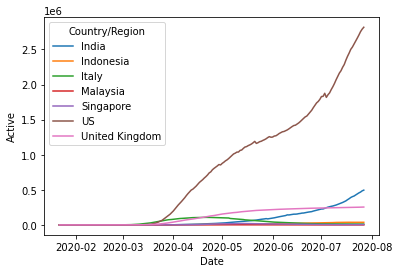

```python
import pandas as pd
import seaborn as sns
import matplotlib.pyplot as plt


covid = pd.DataFrame(pd.read_csv('covid.csv'))
covid_grouped = covid.groupby(['Country/Region', 'Date']).sum().reset_index()
covid_grouped['Date'] = pd.to_datetime(covid_grouped['Date'])

countries = covid_grouped['Country/Region'].isin(['US', 'United Kingdom', 'Italy', 'India', 'Malaysia', 'Singapore', 'Indonesia'])
covid_grouped = covid_grouped[countries]
covid_grouped

sns.lineplot(data = covid_grouped, x='Date', y='Active', hue='Country/Region')
plt.show()
```